# PSTAT 134 Final Project

Eric Livshiz, Jake Vurpillat, Dylan Crookes, Tanveer Singh, Samuel Erlikhman

2026-06-08

## Introduction

We live in the age of streaming services. In the U.S., Netflix, Prime Video, and Disney+ are the most popular, with many households often having many subscriptions. (https://www.statista.com/chart/25382/most-used-video-streaming-platforms/?srsltid=AfmBOoox1XeLW3YlbDt9wzhbtbIxPH0Cxz3AqZt9FTke_DGyZl5rTXjR). While it’s nice to have options, users may start to feel choice overload with the amount of content to choose from; having too many options can result in no choice. So, a user may spend time scrolling endlessly, with no result (at least we do). So, we thought of a question which many have been thought of before; can we use data to recommend movies that better match a user’s preferences?

This project utilizes recommender systems, as well as natural language processing (NLP). The recommender system is used for finding patterns within the data, and suggest similar films based on common features (i.e., a *Star Wars IV* query may return other *Star Wars* films, or *Indiana Jones* due to Harrison Ford starring in both, or *Jurassic Park*, due to John Williams composing the score of both films). Regarding NLP, a few of the features that define similarity and we intend to use are stored in text format (key plot words as an example). We can of course parse the list and analyze the words individually, but we want to preserve structural representations (think of all the famous movie quotes which will lose meaning otherwise!). We also aim to build an NLP-based chat interface, which allows the user to input a natural query (i.e., “recommend me a movie similar to *Top Gun”*), and receive a useful output.

### Goal

We want to answer the following question: “Can we accurately recommend movies given film metadata, such as genre, keywords, cast, and other relevant features?”, using recommender systems and NLP, as well as to create a user interface to interact with our model

### Data

We are lucky that we are not the only ones who care about statistics and films! There exists plenty of datasets regarding films, and we have chosen to use [The Movies Dataset](https://www.kaggle.com/datasets/rounakbanik/the-movies-dataset/data) from Kaggle, as it contains data for ~45,000 films (we use “film” and “movie” interchangeably throughout this write-up, and want to point this out here to avoid any confusion, let’s hope our model believes there is no difference in these terms as well). The data is collected from [MovieLens](https://grouplens.org/datasets/movielens/latest/), a massive dataset which we will not be using, as it contains 33 million ratings and 86,000 movies, and is not reliant for research, and the details, credits, and keywords are taken from [TMDB API](https://developer.themoviedb.org/docs/getting-started). The dataset contains structured and unstructured data, and we will focus on the following files included:

- `movies_metadata.csv` - overall movie information, i.e., title and genre
- `keywords.csv` - quite useful, as it contains plot-related keywords which are stored as JSON objects
- `credits.csv` - self-explanatory; the information about cast and crew
- `links.csv` - mapping between the MovieLens, TMDB, and IMDB identifiers

The dataset includes two more CSVs, `links_small.csv` and `ratings_small.csv`, which are a subset of 9,000 movies - we want to work with the larger dataset to be more accurate, and we are not sure how the subset was selected (we are not sure if it is random, the first 9,000, or what algorithm what used to select the subset). It is important to note, that this dataset was last updated in 2017, meaning our dataset is missing thousands of recent movies. Looking at the above example, a natural similar film to *Top Gun* would be *Top Gun: Maverick*, which came out in 2022, but our system would fail to recommend it.

### Methodology

We’d like to introduce how we will build our recommendation and NLP systems.

#### Recommendation System

This project stems from a content-based recommender systems, meaning that movies are recommended based on their similarity to other movies. This “similarity” is taken from film characteristics, i.e., genre and cast. We will implement this idea by making each movie a feature vector based on its attributes, we will use a similarity measure to be able to compare the movies, compute similarity score, and output the best n options. This can be achieved by using cosine similarity, where $cos(\theta) = \frac{A \cdot B}{||A|| ||B||}$ . We measure the angle between two feature vectors, where $A$ and $B$ are two movies. The numerator is the dot product, meaning the overlap of the films’ features, and the denominator normalizes given the length of vector. The resulting value is from -1 to 1; -1 means that the films are absolute opposites, whereas 1 means that the movies are almost identical (think *Mission Impossible* films). Cosine similarity is quite useful in our context as it focuses on feature patterns, rather than the scale.

#### NLP

Natural language processing is used in this project to understand text-based movie features, as well as for user interaction. As previously mentioned, the keywords and cast lists are stored in a text format and are not easily interpreted by a computer. One way to deal with this data is to find the most useful text-based features (genre and keyword, versus studio or release date). We merge these features into a text representation for each movie (which is referred to as a bag of words), and convert the text to numerical representation using the Term Frequency-Inverse Document Frequency (TF-IDF) method. This process assigns weights to words based on how important it is to the entire dataset $TF-IDF(t, d) = TF(t, d) \cdot log(\frac{N}{DF(t)})$. We can then feed natural sentences to a chatbot, have it process the query, and formulate it into a proper query to the recommender system. Let’s go ahead and get started with the data cleaning.

## Data Cleaning

### Dataset Introduction

Let’s start by introducing the datasets provided:

```r
source("R/02_load_data.R")
```

Let’s explore each dataset individually.

### Individual Dataset Cleaning

Keywords:

```r
head(keywords, n = 2) %>% kable()
```

| id | keywords |
| --- | --- |
| 862 | [{‘id’: 931, ‘name’: ‘jealousy’}, {‘id’: 4290, ‘name’: ‘toy’}, {‘id’: 5202, ‘name’: ‘boy’}, {‘id’: 6054, ‘name’: ‘friendship’}, {‘id’: 9713, ‘name’: ‘friends’}, {‘id’: 9823, ‘name’: ‘rivalry’}, {‘id’:… |
| 8844 | [{‘id’: 10090, ‘name’: ‘board game’}, {‘id’: 10941, ‘name’: ‘disappearance’}, {‘id’: 15101, ‘name’: “based on children’s book”}, {‘id’: 33467, ‘name’: ‘new home’}, {‘id’: 158086, ‘name’: ‘recluse’}, {… |

Here we see two columns, `id` for the movie ID, as well as a JSON string representing keywords, which convenitently have IDs as well. No need to remove anything from this data.

Links:

```r
head(links, n = 2) %>% kable()
```

| movieId | imdbId | tmdbId |
| --- | --- | --- |
| 1 | 0114709 | 862 |
| 2 | 0113497 | 8844 |

Here we see a map of 3 different IDs. We notice that `tmbdId` correlates with the ID from `keywords`. Eventually, we will need to merge data to be one dataset, so let’s keep this dataset as well.

Ratings:

```r
head(ratings, n = 2) %>% kable()
```

| userId | movieId | rating | timestamp |
| --- | --- | --- | --- |
| 1 | 110 | 1.0 | 1425941529 |
| 1 | 147 | 4.5 | 1425942435 |

Here’s a new ID variable, `userId`. We also see `timestamp`, which looks like the timestamp of when the movie was rated. Not very useful for us; we know when the movie was released and don’t care when the film was watched.

```r
ratings_clean <- clean_ratings(ratings)
```

Movies: For the movie metadata dataset, as it has 24 columns. We don’t need to display all of them (as they will not fit in the resulting document), and not all of them are useful. Let’s get rid of the less useful columns, and then display the rest:

```r
movies_clean <- trim_movies_metadata(movies)

head(movies_clean, n = 2) %>% kable()
```

| adult | belongs_to_collection | budget | genres | id | imdb_id | original_language | overview | popularity | production_companies | production_countries | release_date | revenue | runtime | spoken_languages | tagline | title | vote_average | vote_count |
| --- | --- | --- | --- | --- | --- | --- | --- | --- | --- | --- | --- | --- | --- | --- | --- | --- | --- | --- |
| FALSE | {‘id’: 10194, ‘name’: ‘Toy Story Collection’, ‘poster_path’: ‘/7G9915LfUQ2lVfwMEEhDsn3kT4B.jpg’, ‘backdrop_path’: ‘/9FBwqcd9IRruEDUrTdcaafOMKUq.jpg’} | 3.0e+07 | [{‘id’: 16, ‘name’: ‘Animation’}, {‘id’: 35, ‘name’: ‘Comedy’}, {‘id’: 10751, ‘name’: ‘Family’}] | 862 | tt0114709 | en | Led by Woody, Andy’s toys live happily in his room until Andy’s birthday brings Buzz Lightyear onto the scene. Afraid of losing his place in Andy’s heart, Woody plots against Buzz. But when circumstan… | 21.94694 | [{‘name’: ‘Pixar Animation Studios’, ‘id’: 3}] | [{‘iso_3166_1’: ‘US’, ‘name’: ‘United States of America’}] | 1995-10-30 | 373554033 | 81 | [{‘iso_639_1’: ‘en’, ‘name’: ‘English’}] | NA | Toy Story | 7.7 | 5415 |
| FALSE | NA | 6.5e+07 | [{‘id’: 12, ‘name’: ‘Adventure’}, {‘id’: 14, ‘name’: ‘Fantasy’}, {‘id’: 10751, ‘name’: ‘Family’}] | 8844 | tt0113497 | en | When siblings Judy and Peter discover an enchanted board game that opens the door to a magical world, they unwittingly invite Alan – an adult who’s been trapped inside the game for 26 years – into the… | 17.01554 | [{‘name’: ‘TriStar Pictures’, ‘id’: 559}, {‘name’: ‘Teitler Film’, ‘id’: 2550}, {‘name’: ‘Interscope Communications’, ‘id’: 10201}] | [{‘iso_3166_1’: ‘US’, ‘name’: ‘United States of America’}] | 1995-12-15 | 262797249 | 104 | [{‘iso_639_1’: ‘en’, ‘name’: ‘English’}, {‘iso_639_1’: ‘fr’, ‘name’: ‘Français’}] | Roll the dice and unleash the excitement! | Jumanji | 6.9 | 2413 |

We won’t display or change the `credits` dataset, as the `cast` and `crew` columns are stored as JSON strings, and are quite lengthy.

### Merging

Let’s now go ahead and merge datasets. We see the following mapping: movies$id = tmdbId keywords$id = tmdbId credits$id = tmdbId ratings$movieId = MovieLens Id

```r
movies_full <- merge_movies_keywords_credits(movies_clean, keywords, credits)

ratings_join_out <- map_ratings_to_tmdb_summaries(ratings_clean, links)
ratings_mapped <- ratings_join_out$ratings_mapped
ratings_summary <- ratings_join_out$ratings_summary

movies_final <- join_rating_summaries(movies_full, ratings_summary)
```

Let’s take a look at the column names of this final dataset which we’ll use for our analysis:

```r
tibble(dataset = "movies_final",
       columns = paste(colnames(movies_final),
       collapse = ", ")) %>% kable(col.names = c("Dataset", "Columns"))
```

| Dataset | Columns |
| --- | --- |
| movies_final | adult, belongs_to_collection, budget, genres, id, imdb_id, original_language, overview, popularity, production_companies, production_countries, release_date, revenue, runtime, spoken_languages, taglin… |

### Tidying

Let’s see if we can make a few columns look nicer. Taking a look at original language, we see that the character values are two-letter ISO 639-1 language codes:

```r
movies_final %>%
  distinct(original_language) %>%
  head(n = 5) %>%
  kable()
```

| original_language |
| --- |
| en |
| fr |
| zh |
| it |
| fa |

Let’s map them to the full language name:

```r
movies_final <- map_original_language_to_names(movies_final)

movies_final %>%
  distinct(original_language) %>%
  head(n = 5) %>%
  kable()
```

| original_language |
| --- |
| English |
| French |
| Chinese |
| Italian |
| Persian |

Much better. Let’s rename a few columns to be more accurate as well, and add a `year` column, which will be useful for EDA

```r
movies_final <- rename_tmdb_vote_columns(movies_final)
```

### Removing Data

Before cleaning the data further, let’s try understand our dataset a bit better. We should check our data’s dimensions and remove any duplicated rows by ID:

```r
dedupe_out <- dedupe_movies_final_with_summary(movies_final)
dataset_summary <- dedupe_out$dataset_summary
movies_final <- dedupe_out$movies_final

dataset_summary %>%
  kable(caption = "Dataset Summary")
```

Dataset Summary

[output not shown]

```r
missing_summary <- compute_missingness_long(movies_final)

missing_summary %>%
  kable(
    digits = 2,
    caption = "Percentage of Missing Values by Column"
  )
```

Percentage of Missing Values by Column

| column | missing_pct |
| --- | --- |
| belongs_to_collection | 90.12 |
| tagline | 55.10 |
| overview | 2.11 |
| avg_user_rating | 1.59 |
| num_user_ratings | 1.59 |
| original_language | 0.77 |
| runtime_minutes | 0.57 |
| release_date | 0.19 |
| release_year | 0.19 |
| imdb_id | 0.04 |
| tmdb_popularity | 0.01 |
| revenue | 0.01 |
| spoken_languages | 0.01 |
| title | 0.01 |
| tmdb_vote_average | 0.01 |
| tmdb_vote_count | 0.01 |
| production_companies | 0.01 |
| production_countries | 0.01 |
| keywords | 0.00 |
| cast | 0.00 |
| crew | 0.00 |
| adult | 0.00 |
| budget | 0.00 |
| id | 0.00 |
| genres | 0.00 |

In the grand scheme of things, this is a pretty clean dataset! Let’s go column by column. `belongs_to_collection` can easily be removed. Not every film is part of a collection, and while the first and second films in a collection may be closely related to each other and may be the best recommendation, we aim to achieve this similarity using other features, such as cast and film name. We will impute `tagline` and replace with an empty string, which will mean that there is no tagline. A tagline can have useful information, and missingness is too high (55%) for imputing. We will do the same for `overview`, even if there’s only 2% missing.

Numeric columns can be imputed by using the median, and we will do so for `avg_user_rating`, `num_user_ratings`, and `runtime`. The other rows (`release_date`, `imdb_id`, `original_language`, and all others) all have missingness less than 4%, so we’d be removing very few rows overall.

```r
movies_clean <- impute_and_drop_for_modeling(movies_final)

sum(is.na(movies_clean)) %>% kable()
```

| x |
| --- |
| 0 |

Now we are left with 113 films less, and can confidently start our EDA.

## EDA

### Distribution of Ratings

Let’s take a look the distribution of ratings:

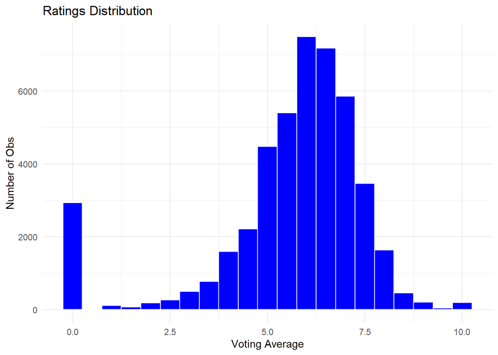

```r
ggplot(movies_clean, aes(tmdb_vote_average)) +
  geom_histogram(binwidth=0.5, fill = "blue", color = "white") +
  labs(
    title = "Ratings Distribution",
    x = "Voting Average",
    y = "Number of Obs"
  ) +
  theme_minimal()
```

This is expected; users seem to be more likely to either give a “slightly above average” rating, or a complete dislike, i,e, 0. Few usually give full marks. So the data is slightly skewed to the left.

### Ratings Count

Let’s also take a look at ratings count - it’s expected that there’s most likely some correlation with more popular films, i.e., films with hundreds of millions for a budget or films that are generally rated higher

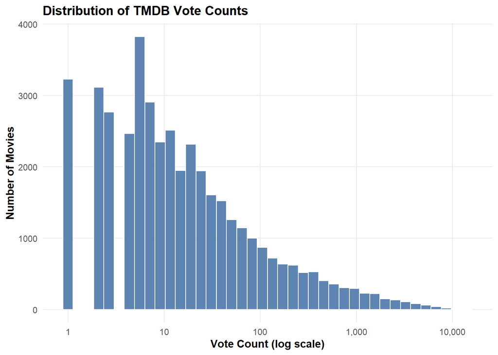

```r
ggplot(movies_clean, aes(x = tmdb_vote_count)) +
  geom_histogram(
    bins = 40,
    fill = "#4C78A8",
    color = "white",
    alpha = 0.9
  ) +
  scale_x_log10(labels = scales::comma) +
  labs(
    title = "Distribution of TMDB Vote Counts",
    x = "Vote Count (log scale)",
    y = "Number of Movies"
  ) +
  theme_minimal() +
  theme(
    plot.title = element_text(face = "bold"),
    plot.subtitle = element_text(color = "gray40"),
    axis.title = element_text(face = "bold"),
    panel.grid.minor = element_blank()
  )
```

We see a long tail, with the data skewed to the right. This again, does make sense - most films don’t receive many ratings. Think of how many blockbuster films come out per year relative to all “other” films. This most most likely can be seen in any data that has popularity attached to it, and the movie industry is no different.

### Movies by Year

Let’s take a look at comparing movies and their release date. It’s likely that more films were released in recent times. It would be interesting to have included more recent data, due to COVID-19 and recent strikes in the film industry. Still, let’s see if there are any visible trends:

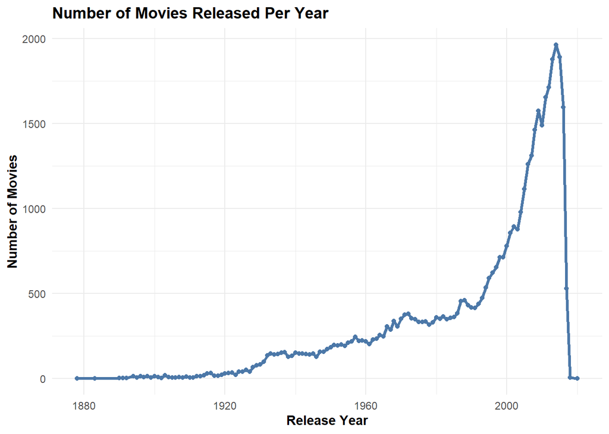

```r
plot_movies_per_year(movies_clean)
```

What’s going on here? We see what looks to be an exponential increase, which does make sense (growth of industry, technological advances for animation and CGI), but we see a sudden drop towards the end of the data. Most likely, there’s entries about films which would be released after 2017 (the cutoff of the data, so there aren’t many datapoints for later dates). Let’s take a closer look:

```r
movies_clean %>%
  filter(release_year > 2015) %>%
  select(title, tmdb_vote_count, release_year) %>%
  count(release_year, sort = TRUE) %>%
  kable()
```

| release_year | n |
| --- | --- |
| 2016 | 1596 |
| 2017 | 530 |
| 2018 | 5 |
| 2020 | 1 |

So we see a few things happening. First, reviewers had left reviews for unreleased films - they are time travelers! Let’s remove these films from the data. Second, as this dataset has a cutoff of July 2017, according to its description, so about half of the films released in 2017 are missing, which explains the drop.

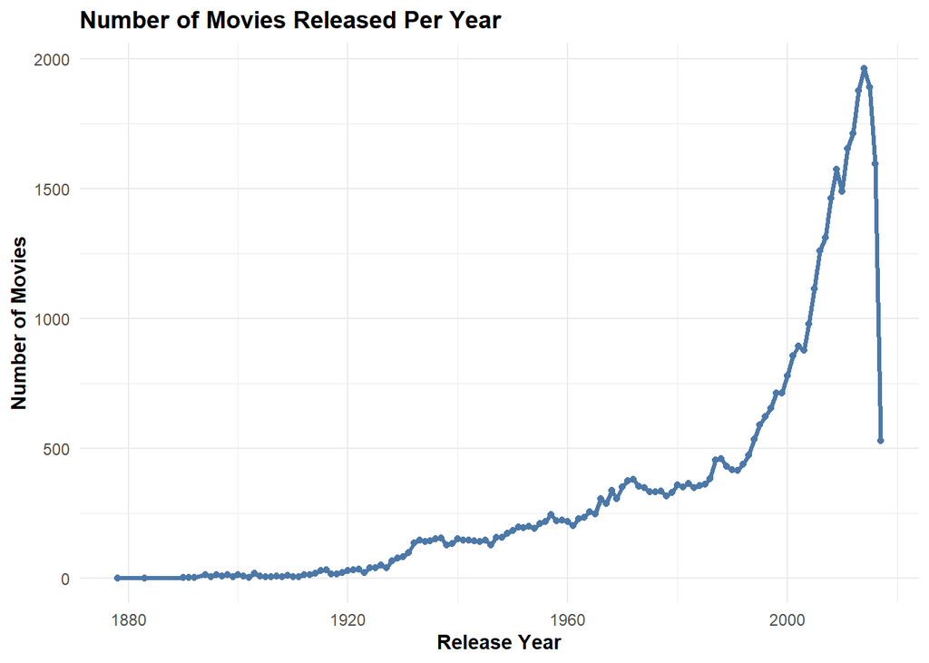

```r
movies_clean <- filter_movies_released_through_year(movies_clean, 2017L)

plot_movies_per_year(movies_clean)
```

# The Modeling

Now with all the data cleaning and visualizations we have seen above, its now time to get into the most important part of this process, building the NLP and recommender models.

## NLP Model

### Tokenizing

For the NLP model, as discussed prior we will be taking a text representation of each movie and changing it into a query for the Recommender system. To start we must go through a process called tokenization, where each word or word group will begin to be paired together in order to better identify what each word may represent.

```r
movies_text <- make_movies_text(movies_clean)


movies_tokens <- make_movie_tokens(movies_text
                                   )
movies_tokens %>%
  head(30)
```

| id | title | word |
| --- | --- | --- |
| 862 | Toy Story | toy |
| 862 | Toy Story | story |
| 862 | Toy Story | id |
| 862 | Toy Story | 16 |
| 862 | Toy Story | animation |
| 862 | Toy Story | id |
| 862 | Toy Story | 35 |
| 862 | Toy Story | comedy |
| 862 | Toy Story | id |
| 862 | Toy Story | 10751 |

[output cut: 20 more lines]

So now we have a dataset of 17 million words, which is a extremely large dataset. As you can see from the first 30 entries, theyre all representing the same movie, this is because when tokenizing each word gets its own row, which is how we got such a large dataset. So lets look a little deeper at how many words are represented and the impact they may have.

```r
movies_tokens %>%
  count(word, sort = T) %>%
  head(30) %>%
  kbl() %>%
  scroll_box(height = "500px")
```

| word | n |
| --- | --- |
| id | 245602 |
| drama | 21259 |
| 18 | 20312 |
| comedy | 15747 |
| 35 | 13125 |
| life | 9581 |
| film | 9327 |
| family | 8865 |
| love | 8653 |
| thriller | 8028 |
| romance | 7674 |
| woman | 7560 |
| 53 | 7522 |
| action | 7151 |
| 10749 | 6682 |
| world | 6457 |
| 28 | 6419 |
| story | 6125 |
| war | 5943 |
| crime | 5797 |
| documentary | 5763 |
| horror | 5582 |
| time | 4731 |
| 27 | 4699 |
| adventure | 4504 |
| 80 | 4304 |
| director | 4263 |
| father | 4216 |
| 99 | 3934 |
| 12 | 3786 |

As seen above, the word id seems to have the most words appearing, while the rest of the words seem to be more in line with movie plots or summaries, so lets remove id so it wont have a larger impact on the model than it needs to, especially with almost 250,000 seen values of it.

```r
movies_tokens_clean <- clean_movie_tokens(movies_tokens)

movies_tokens_clean %>%
  count(word, sort = T) %>%
  head(30) %>%
  kbl() %>%
  scroll_box(height = "500px")
```

| word | n |
| --- | --- |
| drama | 21259 |
| 18 | 20312 |
| comedy | 15747 |
| 35 | 13125 |
| life | 9581 |
| film | 9327 |
| family | 8865 |
| love | 8653 |
| thriller | 8028 |
| romance | 7674 |
| woman | 7560 |
| 53 | 7522 |
| action | 7151 |
| 10749 | 6682 |
| world | 6457 |
| 28 | 6419 |
| story | 6125 |
| war | 5943 |
| crime | 5797 |
| documentary | 5763 |
| horror | 5582 |
| time | 4731 |
| 27 | 4699 |
| adventure | 4504 |
| 80 | 4304 |
| director | 4263 |
| father | 4216 |
| 99 | 3934 |
| 12 | 3786 |
| girl | 3655 |

With id being removed, we now have an ideal token set to be able to build our TF-IDF.

### TF-IDF

Now using the Tf-Idf method, we can determine what words relate most with certain movies, so lets begin that process now.

```r
movie_tf_idf <- make_word_tf_idf(movies_tokens_clean)

movie_tf_idf %>%
  head(30)
```

| id | word | n | tf | idf | tf_idf |
| --- | --- | --- | --- | --- | --- |
| 37603 | diversant | 1 | 1 | 10.713840 | 10.713840 |
| 52150 | zincirbozan | 1 | 1 | 10.713840 | 10.713840 |
| 54566 | millipilleri | 1 | 1 | 10.713840 | 10.713840 |
| 57342 | amnèsia | 1 | 1 | 10.713840 | 10.713840 |
| 64948 | bix | 1 | 1 | 10.713840 | 10.713840 |
| 68646 | superprodukcja | 1 | 1 | 10.713840 | 10.713840 |
| 74921 | ajlawju | 1 | 1 | 10.713840 | 10.713840 |
| 76746 | vdrebezgi | 1 | 1 | 10.713840 | 10.713840 |
| 105766 | musikanten | 1 | 1 | 10.713840 | 10.713840 |
| 107525 | saippuaprinssi | 1 | 1 | 10.713840 | 10.713840 |

[output cut: 20 more lines]

As a result, we now have what the most common word is for individual movies, with the highest score of tf_idf being from non-english films, as our dataset contains all released movies, not just those from the west.

### Bigrams

While singular word outputs can provide strong information, in terms of movies a lot of two grouped phrases will provide much stronger insights into what a movie may relate to. For instance, word combos like space battle could help when identifying movies like Star Wars and Star trek.

```r
movie_bigrams <- make_bigram_tokens(movies_text)

movies_bigrams_clean <- clean_bigram_tokens(movie_bigrams)

movies_bigrams_clean %>%
  count(bigram, sort = T) %>%
  head(30) %>%
  kbl() %>%
  scroll_box(height = "500px")
```

| bigram | n |
| --- | --- |
| science fiction | 3140 |
| woman director | 3027 |
| independent film | 1920 |
| world war | 1163 |
| tv movie | 911 |
| war ii | 819 |
| true story | 790 |
| los angeles | 692 |
| york city | 671 |
| serial killer | 606 |
| female nudity | 555 |
| martial arts | 438 |
| civil war | 377 |
| love story | 345 |
| silent film | 339 |
| film noir | 328 |
| son relationship | 283 |
| road trip | 281 |
| san francisco | 267 |
| romantic comedy | 265 |
| police officer | 254 |
| daughter relationship | 247 |
| father son | 243 |
| london england | 235 |
| love triangle | 229 |
| sister relationship | 224 |
| male nudity | 223 |
| true love | 217 |
| 19th century | 213 |
| fairy tale | 210 |

As seen from the list above, we have the most common word combinations across films, a lot of which makes since. For instance, sci-fi is one of the leading movie themes, so it is reflected as the most common word combination. So using these we will make a TF-IDF for the bigrams

```r
bigram_tf_idf <- make_bigram_tf_idf(movies_bigrams_clean)

bigram_tf_idf %>%
  head(30)
```

| id | title | bigram | n | tf | idf | tf_idf |
| --- | --- | --- | --- | --- | --- | --- |
| 58081 | Iris Blond | iris blond | 2 | 1 | 10.70565 | 10.70565 |
| 98010 | Francis of Assisi | lusty fighting | 2 | 1 | 10.70565 | 10.70565 |
| 265934 | Tommy Cooper: Not Like That, Like This | tommy cooper | 2 | 1 | 10.70565 | 10.70565 |
| 323555 | That Gal...Who Was in That Thing: That Guy 2 | guy 2 | 2 | 1 | 10.70565 | 10.70565 |
| 80 | Before Sunset | strangers met | 1 | 1 | 10.70565 | 10.70565 |
| 4652 | The Golden Goose | golden goose | 1 | 1 | 10.70565 | 10.70565 |
| 5201 | Wild Orchids | wild orchids | 1 | 1 | 10.70565 | 10.70565 |
| 5595 | Fermat's Room | mysterious host | 1 | 1 | 10.70565 | 10.70565 |
| 5899 | The Northerners | neighbor life | 1 | 1 | 10.70565 | 10.70565 |
| 6173 | Read My Lips | lip reads | 1 | 1 | 10.70565 | 10.70565 |

[output cut: 20 more lines]

Similar to the single word tf-idf, we see that there is a very high tf-idf score for films, however the number of appearances tends to be lower, so lets set a minimum appearance of 3 in order to remove rarer word combos.

```r
bigram_tf_idf_top <- clean_bigram_tf_idf(bigram_tf_idf)

bigram_tf_idf_clean <- bigram_tf_idf %>%
  semi_join(bigram_tf_idf_top, by = "bigram")

bigram_tf_idf_clean %>%
  head(30)
```

| id | title | bigram | n | tf | idf | tf_idf |
| --- | --- | --- | --- | --- | --- | --- |
| 60498 | The Legend of the Candy Cane | candy cane | 2 | 1 | 9.607034 | 9.607034 |
| 12154 | Three Men and a Baby | baby left | 1 | 1 | 9.607034 | 9.607034 |
| 28118 | The Gruffalo | magical tale | 1 | 1 | 9.607034 | 9.607034 |
| 31459 | It Runs in the Family | york family | 1 | 1 | 9.607034 | 9.607034 |
| 35113 | I Want You | obsessive pursuit | 1 | 1 | 9.607034 | 9.607034 |
| 40882 | The Mirror | mother doesn | 1 | 1 | 9.607034 | 9.607034 |
| 42062 | Moontide | drunken night | 1 | 1 | 9.607034 | 9.607034 |
| 50845 | The Clink of Ice | alcoholic writer | 1 | 1 | 9.607034 | 9.607034 |
| 52907 | Waltzes from Vienna | johann strauss | 1 | 1 | 9.607034 | 9.607034 |
| 53425 | A Day's Pleasure | moving van | 1 | 1 | 9.607034 | 9.607034 |

[output cut: 20 more lines]

So now more common bigrams are used here rather than rarer ones, making the tf-idf more reliable and not reliant on outliers as much.

### Preparing for recommender

The last thing we need to do is prepare the NLP for the recommender, so we will create a feature matrix, where we take the tf_idfs and assign them a value based on the movie they are most related too.

```r
movie_search <- movies_text %>%
  distinct(id, title, release_year, tmdb_vote_average, tmdb_popularity)
```

```r
movies_feature_matrix <- create_feature_matrix(bigram_tf_idf_clean)
```